# Lab-4: Assignment

Author

Dr. Purna Gamage

## Problem 1:

Use simulation to answer the following questions.

Given independent uniform random variables $X_1 \sim U(a, b)$ and $X_2 \sim U(a,b)$. (You can use parameters of your choice)

```r
library(ggplot2)
library(tidyverse)
# library(plotly)
```

1. Is the distribution of $X_1 +X_2$ uniform? Please Justify your answer.

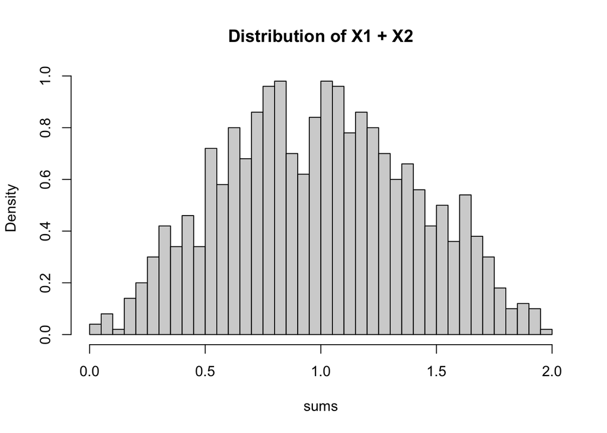

```r
lower <- 0
upper <- 1

samples <- 1000

x1 <- runif(samples, min = lower, max = upper)
x2 <- runif(samples, min = lower, max = upper)

sums <- x1 + x2

hist(sums, breaks = 50, prob = TRUE, main = "Distribution of X1 + X2")
```

2. Is the distribution of $X_1.X_2$ uniform? Please Justify your answer.

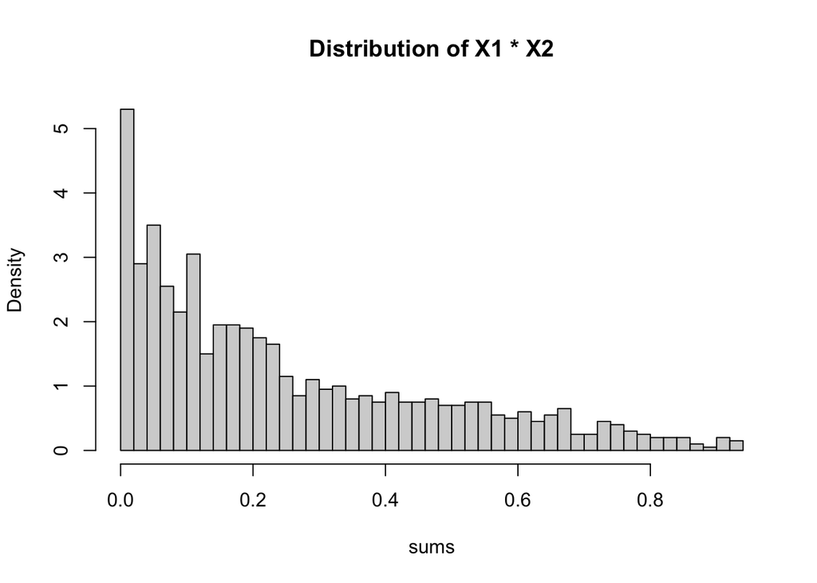

```r
lower <- 0
upper <- 1

samples <- 1000

x1 <- runif(samples, min = lower, max = upper)
x2 <- runif(samples, min = lower, max = upper)

sums <- x1 * x2

hist(sums, breaks = 50, prob = TRUE, main = "Distribution of X1 * X2")
```

3. Is the distribution of $max(X_1, X_2)$ or $min(X_1, X_2)$ uniform? Please Justify your answer.

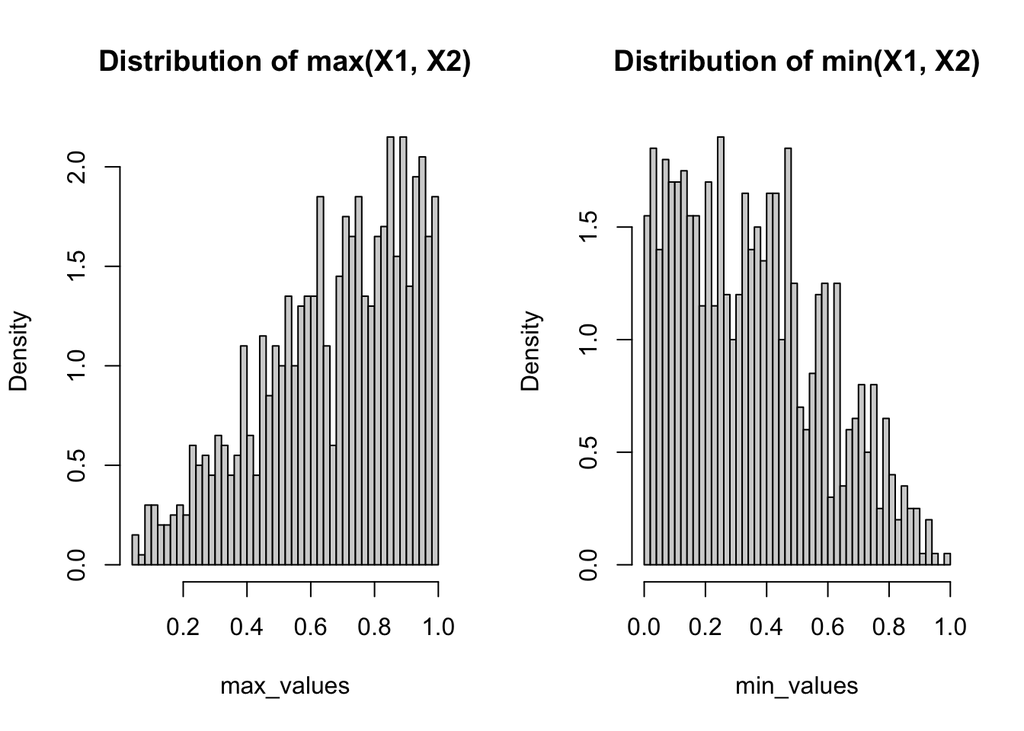

```r
lower <- 0
upper <- 1

samples <- 1000

max_values <- numeric(samples)
min_values <- numeric(samples)

for (i in 1:samples) { # simulation
  x1 <- runif(1, min = lower, max = upper)
  x2 <- runif(1, min = lower, max = upper)

  max_values[i] <- max(x1, x2)
  min_values[i] <- min(x1, x2)
}
# create a plot
par(mfrow = c(1, 2))

# MAX
hist(max_values, breaks = 50, prob = TRUE, main = "Distribution of max(X1, X2)")
# MIN
hist(min_values, breaks = 50, prob = TRUE, main = "Distribution of min(X1, X2)")
```

4. Is the distribution of $1-X_1$ uniform? Please Justify your answer.

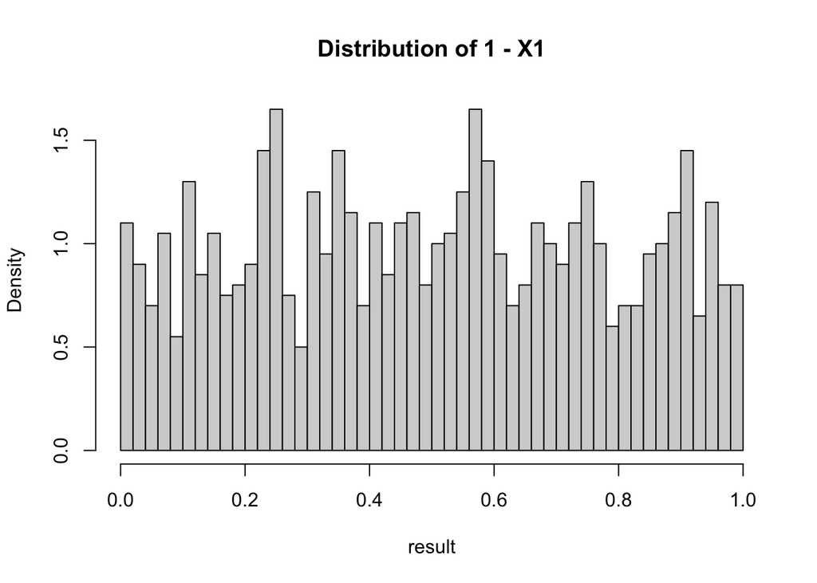

```r
lower <- 0
upper <- 1

samples <- 1000

result <- numeric(samples)

for (i in 1:samples) { # simulation
  x1 <- runif(1, min = lower, max = upper)
  result[i] <- 1 - x1
}

hist(result, breaks = 50, prob = TRUE, main = "Distribution of 1 - X1")
```

## Problem 2:

Validate the following theorems using simulation. (You can use parameters of your choice)

`optional`: In addition to the simulation, you can also prove these theorems analytically, i.e. with pen and paper, if you want.

1. Linear Transformations

**Theorem-5.6.4:** If $X$ has the normal distribution with mean $\mu$ and variance $\sigma^2$ and if $Y=a X+b$, 5.6.4 where $a$ and $b$ are given constants and $a \neq 0$, then $Y$ has the normal distribution with mean $a \mu+b$ and variance $a^2 \sigma^2$.

```r
mu <- 10
sigma <- 2
a <- 3
b <- 5

sim <- 1000

Y_sim <- numeric(sim)

for (i in 1:sim) {
  z <- rnorm(1, mean = 0, sd = 1) # normalization
  Y <- a * (mu + sigma * z) + b
  Y_sim[i] <- Y
}

Y_mean <- mean(Y_sim)
Y_var <- var(Y_sim)
Y_mean
```

```
[1] 35.27034
```

```r
Y_var
```

```
[1] 40.01976
```

```r
Y_real_mean <- a * mu + b
Y_real_var <- a^2 * sigma^2
Y_real_mean
```

```
[1] 35
```

```r
Y_real_var
```

```
[1] 36
```

2. Linear Combinations of Normally Distributed Variables

**Theorem-5.6.7:** If the random variables $X_1, \ldots, X_k$ are independent and if $X_i$ has the normal distribution with mean $\mu_i$ and variance $\sigma_i^2(i=1, \ldots, k)$, then the sum $X_1+\cdots+X_k$ has the normal distribution with mean $\mu_1+\cdots+\mu_k$ and variance $\sigma_1^2+\cdots+\sigma_k^2$.

```r
ind_vars <- 5
sim <- 1000

mu <- c(10, 15, 20, 25, 30)
sigma <- c(4, 9, 16, 25, 36)

sums <- numeric(sim)

for (i in 1:sim) {
  X_values <- rnorm(ind_vars, mean = mu, sd = sqrt(sigma))
  sum_X <- sum(X_values)
  sums[i] <- sum_X
}

sim_mean <- mean(sums)
sim_var <- var(sums)

sim_mean
```

```
[1] 99.9444
```

```r
sim_var
```

```
[1] 94.74156
```

```r
real_mean <- sum(mu)
real_var <- sum(sigma)
real_mean
```

```
[1] 100
```

```r
real_var
```

```
[1] 90
```

## Problem 3:

Use the iris data set to check the normality of Sepal width of setosa using the following normality tests (Repeat the steps in the example 3 in lab 4, comment on your results)

1. Anderson Darling Test

```r
library(nortest)
data(iris)
setosa_data <- iris[iris$Species == "setosa", ]
result <- ad.test(setosa_data$Sepal.Width)
print(result)
```

```
    Anderson-Darling normality test

data:  setosa_data$Sepal.Width
A = 0.49096, p-value = 0.2102
```

2. Kolmogorov-Smirnov Test (Comapre to a standard normal distribution)

```r
data(iris)
setosa_data <- iris[iris$Species == "setosa", ]
result <- ks.test(setosa_data$Sepal.Width, "pnorm", mean = mean(setosa_data$Sepal.Width), sd = sd(setosa_data$Sepal.Width))
print(result)
```

```
    Asymptotic one-sample Kolmogorov-Smirnov test

data:  setosa_data$Sepal.Width
D = 0.10468, p-value = 0.6437
alternative hypothesis: two-sided
```

## Problem 4: (optional)

`Exponential Distribution`

Given exponentially distributed random variables $X_1, . . . , X_k$ . Think of waiting times for independent random alarm clocks $1,...,k$ to go off.

Which of these are again exponentially distributed? Explore with a simulation. (Hint: you can use many methods here to compare the distributions, for example; using Kolmogorov-Smirnov Test, plotting cdfs or ecdfs(as we did in lab 3),..etc )

1. Distribution of $min(X_1,\dots,X_k)$? Waiting time for the first alarm to go off.
2. Distribution of $max(X_1, \dots, X_k )$? Waiting time for the last alarm to go off.
3. Distribution of $X_1 + \dots + X_k$ ? Waiting time until Start of the next clock when the previous alarm/s has gone off.